# Clase 2. Estadística Descriptiva. Medidas de Tendencia Central y dispersión.

#### **1. Instalar paquetes.**

R viene con funciones básicas instaladas (“base R”), pero la verdadera potencia reside en los paquetes externos. Para usarlos, seguimos dos pasos: `instalarlos` (una sola vez en tu computadora, mediante la función `install.packages("nombre_del_paquete")`) y `cargarlos` (cada vez que abras un nuevo script, mediante la función `library("nombre_del_paquete")`).

```r
#Instalar paquete por única vez. Estos son algunos que usaremos esta y la siguientes clases
install.packages("tidyverse") #El nombre del paquete debe estar entre comillas
install.packages("readxl")
install.packages("dplyr")
```

```r
#Cargar paquete cada vez que abras una sesión nueva de RStudio.
library(readxl) #En este caso el nombre del paquete funciona con y sin comillas
library(tidyverse)
library(dplyr)
```

#### **2. Preparación de datos.**

Importamos nuestros datos mediante el botón `import` o bien mediante la función read_excel() del paquete `readxl`. En este caso trabajaremos con la base de datos `Tabla_camelida.xlsx`, la cual puedes encontrar el repositorio del curso o descargar directamente haciendo click [aquí](https://github.com/Arqueologia-Cuantitativa-UC/ANT305Q-2026/blob/main/Clases/Clase2/Tabla%20camelida.xlsx?raw=true).

```r
camelidos <- read_excel("~/Desktop/work/0_Cuantitativa_2026/ANT305Q-2026/Clases/Clase2/Tabla camelida.xlsx")
camelidos
```

```
## # A tibble: 33 × 3
##    Taxon Largo Ancho
##    <chr> <dbl> <dbl>
##  1 LLAMA  80.3  35.4
##  2 LLAMA  71.6  21.2
##  3 LLAMA  70.9  22.0
##  4 LLAMA  70.6  22.3
##  5 LLAMA  69.1  22.7
##  6 LLAMA  68.7  20.8
##  7 LLAMA  67.8  20
##  8 LLAMA  66.6  21
##  9 LLAMA  65.9  20.3
## 10 LLAMA  65.8  21.2
## # ℹ 23 more rows
```

#### **3. Filtrado de datos.**

A menudo necesitamos aislar datos específicos. Para esto, usaremos la función `filter()` junto al operador pipe `(%>%)` disponibles en el paquete `tidyverse`, que funciona como un “entonces”: “toma los datos, y luego fíltralos”. En este caso haremos el ejercicio de filtrar solo los datos provenientes del Taxón llamas. Tanto las variables como los datos a seleccionar deben ser escritos `tal cual como están en la base de datos original.`

```r
# Creamos un nuevo dataframe solo con los datos de LLAMA
llama <- camelidos %>% filter(Taxon == "LLAMA")

# Verificamos el resultado
llama
```

```
## # A tibble: 20 × 3
##    Taxon Largo Ancho
##    <chr> <dbl> <dbl>
##  1 LLAMA  80.3  35.4
##  2 LLAMA  71.6  21.2
##  3 LLAMA  70.9  22.0
##  4 LLAMA  70.6  22.3
##  5 LLAMA  69.1  22.7
##  6 LLAMA  68.7  20.8
##  7 LLAMA  67.8  20
##  8 LLAMA  66.6  21
##  9 LLAMA  65.9  20.3
## 10 LLAMA  65.8  21.2
## 11 LLAMA  65.1  21.6
## 12 LLAMA  64.6  19.3
## 13 LLAMA  64.2  20.0
## 14 LLAMA  61.5  18.7
## 15 LLAMA  61.1  20.3
## 16 LLAMA  60.8  18.8
## 17 LLAMA  60.6  19.9
## 18 LLAMA  60.5  18.9
## 19 LLAMA  56.9  18.8
## 20 LLAMA  40.2  15.2
```

#### **4. Estadísticas Descriptivas.**

Para conocer las medidas de tendencia central y dispersión de nuestra muestra, R nos ofrece múltiples funciones. Podemos usar `summary()` para obtener un resumen general rápido de una variable específica.

Para indicarle a R exactamente qué columna queremos analizar dentro de nuestro dataframe, usamos el signo `$`.

```r
# Resumen estadístico general (Mínimo, Cuartiles, Mediana, Media, Máximo)
summary(llama$Ancho)
```

```
##    Min. 1st Qu.  Median    Mean 3rd Qu.    Max.
##   15.20   19.20   20.28   20.92   21.31   35.40
```

Si necesitamos extraer un valor específico para reportarlo o usarlo en otra fórmula, podemos calcular cada parámetro de forma independiente usando sus funciones específicas:

```r
# Medidas de Tendencia Central
mean(llama$Ancho)   # Media o Promedio
```

```
## [1] 20.9195
```

```r
median(llama$Ancho) # Mediana
```

```
## [1] 20.28
```

```r
# Medidas de Posición y Dispersión
quantile(llama$Ancho) # Cuartiles
```

```
##     0%    25%    50%    75%   100%
## 15.200 19.195 20.280 21.310 35.400
```

```r
IQR(llama$Ancho)      # Rango Intercuartil
```

```
## [1] 2.115
```

```r
sd(llama$Ancho)       # Desviación Estándar (Standard Deviation)
```

```
## [1] 3.792384
```

```r
var(llama$Ancho)      # Varianza
```

```
## [1] 14.38217
```

#### **5. Visualización de datos: Histograma.**

Para explorar visualmente cómo se distribuyen nuestros datos, crearemos un histograma. Para esto usaremos `ggplot2`, un paquete especializado en gráficos que ya viene incluido y cargado dentro de `tidyverse.`

Usaremos la función `ggplot()`. Primero definimos nuestros datos (`data = llama`), luego en `aes()` (aesthetics) definimos qué variable irá en el eje X (en este caso, el Ancho). Finalmente, le indicamos el tipo de gráfico con `geom_histogram()`, donde podemos personalizar el grosor de las barras (`binwidth`), el color del borde y el relleno.

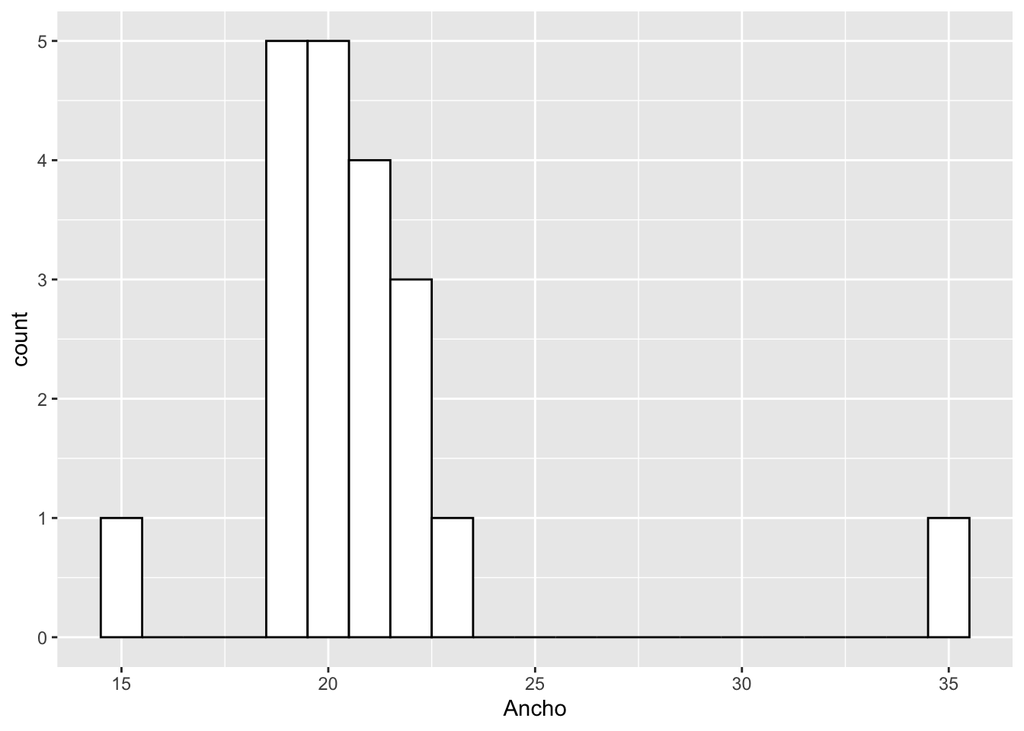

```r
# Histograma para el ancho de falange solo de las llamas
ggplot(data = llama, aes(x = Ancho)) +
  geom_histogram(binwidth = 1, color = "black", fill = "white")
```

Si queremos ver todos los datos en un mismo gráfico para compararlos, ya no usamos el vector filtrado, sino nuestra base de datos original (camelidos).

Para que R diferencie ambos grupos en el gráfico, agregamos el argumento `fill = Taxon` dentro de la función `aes()`. Esto le indica al programa que rellene las barras con colores distintos según la especie.

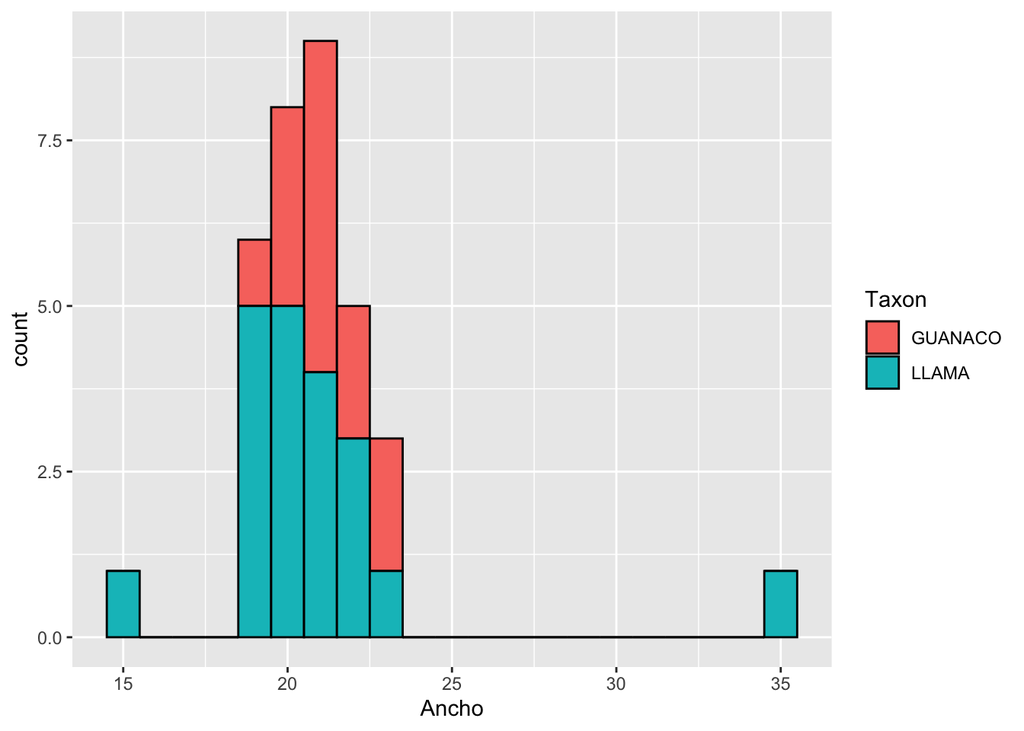

```r
# Histograma comparativo para toda la base de datos
ggplot(data = camelidos, aes(x = Ancho, fill = Taxon)) +
  geom_histogram(binwidth = 1, color = "black")
```

#### **6. Trabajo en Clases 2.**

Utilizando la base de datos `Tabla_camelida.xlsx`, crea un nuevo script y realiza los siguientes ejercicios en R:

1. Explore la variable `Largo` utilizando un histograma (sin filtrar).
2. Explore la variable `Largo` sólo para el taxón “GUANACO” utilizando un histograma.
3. Calcule la media, mediana, máximo, mínimo, 1er y 3er cuartil de la variable `Largo` para el taxón “GUANACO”.
4. Calcule la dispersión media o rango intercuartil (IQR) de la variable `Largo` en “GUANACO”.
5. Calcule la desviación estándar de la variable `Largo` en “GUANACO”.
6. Calcule la varianza de la variable `Largo` en “GUANACO”.
7. Explore la variable `Ancho` utilizando un histograma (sin filtrar).
8. Explore la variable `Ancho` sólo para el taxón “GUANACO” utilizando un histograma.
9. Calcule la media, mediana, máximo, mínimo, 1er y 3er cuartil de la variable `Ancho` para el taxón “GUANACO”.
10. Calcule la dispersión media o rango intercuartil (IQR) de la variable `Ancho` en “GUANACO”.
11. Calcule la desviación estándar de la variable `Ancho` en “GUANACO”.
12. Calcule la varianza de la variable `Ancho` en “GUANACO”.

← Clase Anterior Índice Siguiente Clase →